# Series 6 – ANOVA & ANCOVA

## Bayesian approach

Data show significant variance within groups.

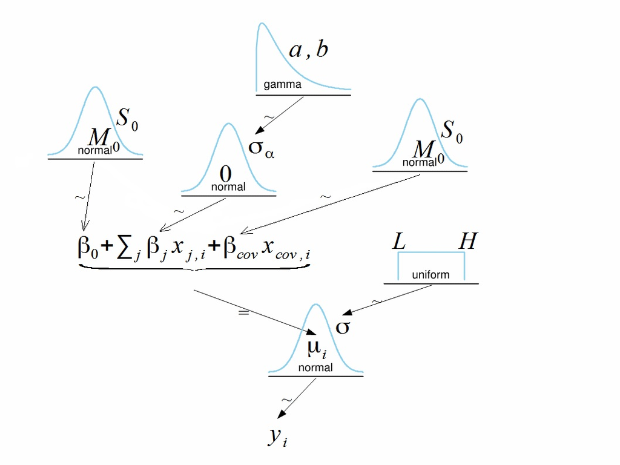

An additional metric predictor that can explain part of that variance.

In this example the subjects of the experiment were in different physical conditions which contributed to large variation of life expectancy.

A metric predictor that is available is the size of the species.

Create data with both predictors.

```r
dataList2<-list(Ntotal=nrow(dta),
                y=dta$Longevity,
                xMet=dta$Thorax,
                xNom=as.integer(as.factor(dta$CompanionNumber)),
                NxLvl=nlevels(as.factor(dta$CompanionNumber)),
                agammaShRa=unlist(gammaShRaFromModeSD(mode=sd(dta$Longevity)/2,
                                                      sd=2*sd(dta$Longevity))))
```

```r
modelString<-"
data {
    int<lower=1> Ntotal;
    real y[Ntotal];
    int<lower=2> NxLvl;
    int<lower=1, upper=NxLvl> xNom[Ntotal];
    real xMet[Ntotal];
    real<lower=0> agammaShRa[2];
}
transformed data {
    real meanY;
    real sdY;
    real xMetMean;
    real xMetSD;
    meanY = mean(y);
    sdY = sd(y);
    xMetMean = mean(xMet);
    xMetSD = sd(xMet);
}
parameters {
    real a0;
    real<lower=0> aSigma;
    vector[NxLvl] a;
    real aMet;
    real<lower=0> ySigma;
}
model {
    a0 ~ normal(meanY, 5*sdY);
    aSigma ~ gamma(agammaShRa[1], agammaShRa[2]);
    a ~ normal(0, aSigma);
    aMet ~ normal(0, 2*sdY/xMetSD);
    ySigma ~ uniform(sdY/100, sdY*10);
    for ( i in 1:Ntotal ) {
        y[i] ~ normal(a0 + a[xNom[i]] + aMet*(xMet[i] - xMetMean), ySigma);
    }
}
generated quantities {
    // Convert a0,a[] to sum-to-zero b0,b[] :
        real b0;
    vector[NxLvl] b;
    b0 = a0 + mean(a) - aMet * xMetMean;
    b = a - mean(a);
}
"
```

```r
model2 <- stan_model(model_code=modelString)
```

If saved DSO is used load it, then run the chains.

```r
# saveRDS(model2, file="data/stanDSO2.Rds")
model2 <- readRDS("data/stanDSO2.Rds")
```

Run MCMC.

```r
fit2 <- sampling(model2,
                data=dataList2,
                pars=c('b0', 'b', 'aMet', 'aSigma', 'ySigma'),
                iter=5000, chains = 2, cores = 4)
```

```r
launch_shinystan(fit2)
```

Calculate same contrasts for betas:

1. Contrasts between group 1 (‘None0’) and 5 (‘Virgin8’).

```r
fit_ext2 <- rstan::extract(fit2)
head(fit_ext2$b)
```

```
iterations     [,1]     [,2]     [,3]       [,4]      [,5]
      [1,] 4.466494 6.207247 3.940179 -0.8029348 -13.81098
      [2,] 7.582592 4.825399 6.512522 -5.6358837 -13.28463
      [3,] 6.948511 7.865498 6.695544 -6.7136045 -14.79595
      [4,] 4.922978 7.802200 6.146581 -5.6397349 -13.23202
      [5,] 7.228799 5.271264 6.506355 -5.4617319 -13.54469
      [6,] 3.844551 8.005606 6.024163 -5.0992662 -12.77505
```

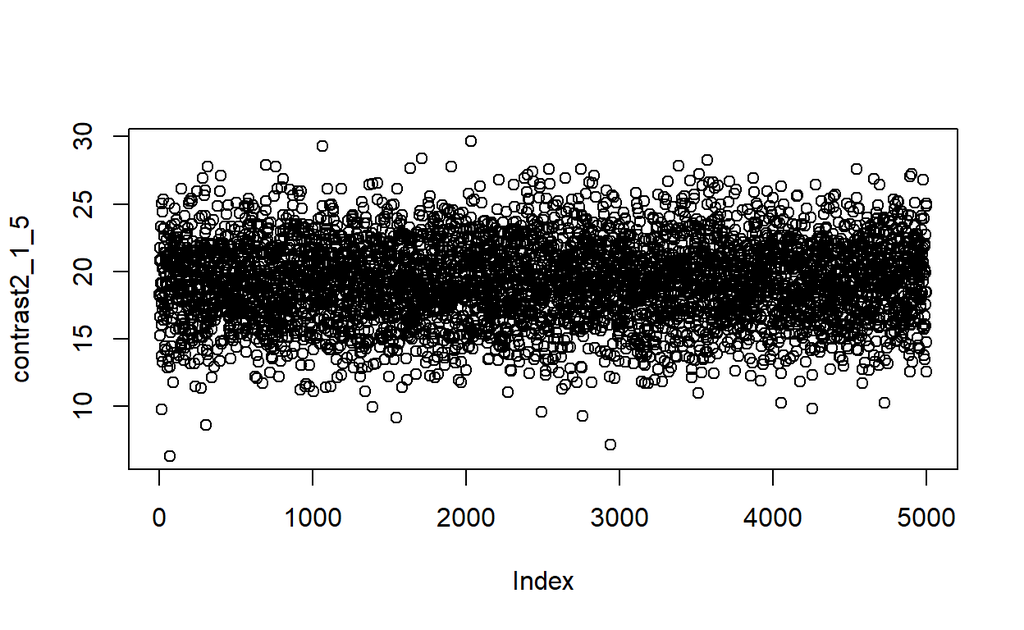

```r
contrast2_1_5 <- fit_ext2$b[,1] - fit_ext2$b[,5]
plot(contrast2_1_5)
```

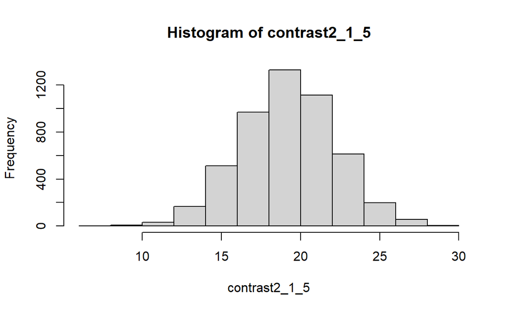

```r
hist(contrast2_1_5)
```

```r
(hdiContrast2_1_5<-hdi(contrast2_1_5))
```

```
   lower    upper
13.40625 25.09579
attr(,"credMass")
[1] 0.95
```

```r
(sd.contrast2_1_5<-sd(contrast2_1_5))
```

```
[1] 2.995819
```

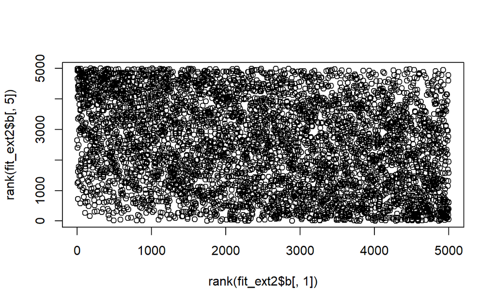

```r
plot(rank(fit_ext2$b[,1]),rank(fit_ext2$b[,5]))
```

2. Contrast between average of groups 1-3 and average of groups 4-5

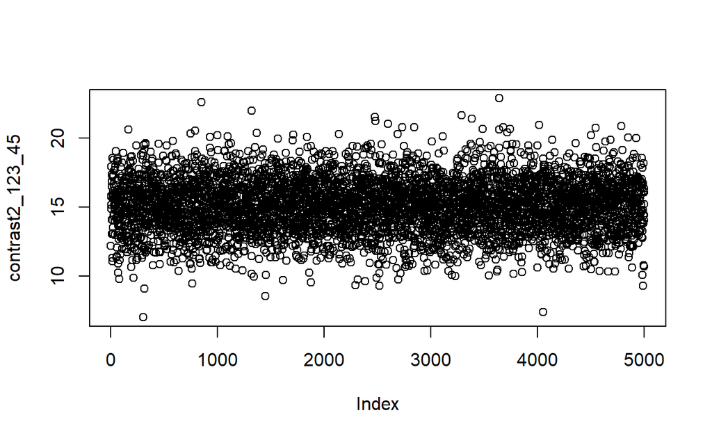

```r
Comb1<-(fit_ext2$b[,1] + fit_ext2$b[,2] + fit_ext2$b[,3])/3
Comb2<-(fit_ext2$b[,4] + fit_ext2$b[,5])/2
contrast2_123_45 <-Comb1-Comb2
plot(contrast2_123_45)
```

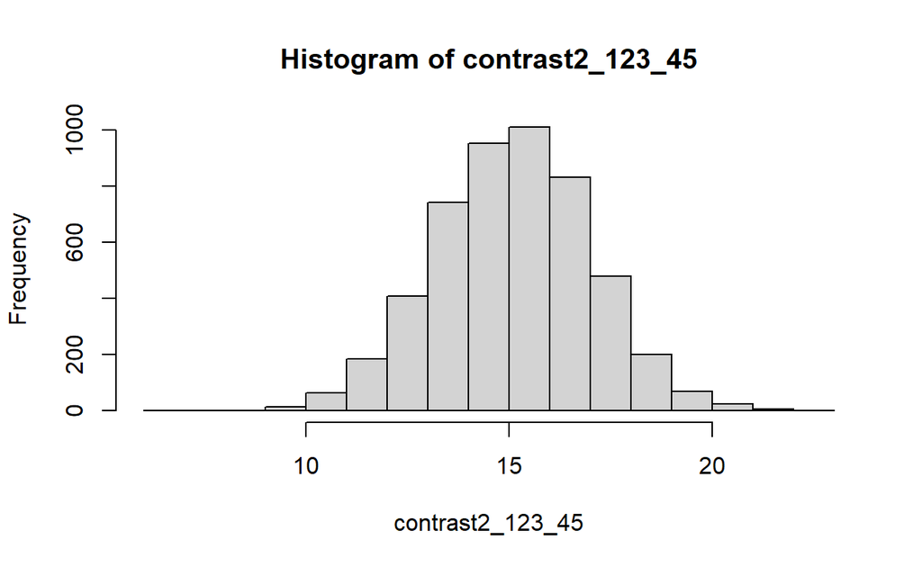

```r
hist(contrast2_123_45)
```

```r
(hdiContrast2_123_45<-hdi(contrast2_123_45))
```

```
   lower    upper
11.28173 18.74789
attr(,"credMass")
[1] 0.95
```

```r
(sd.contrast2_123_45<-sd(contrast2_123_45))
```

```
[1] 1.910106
```

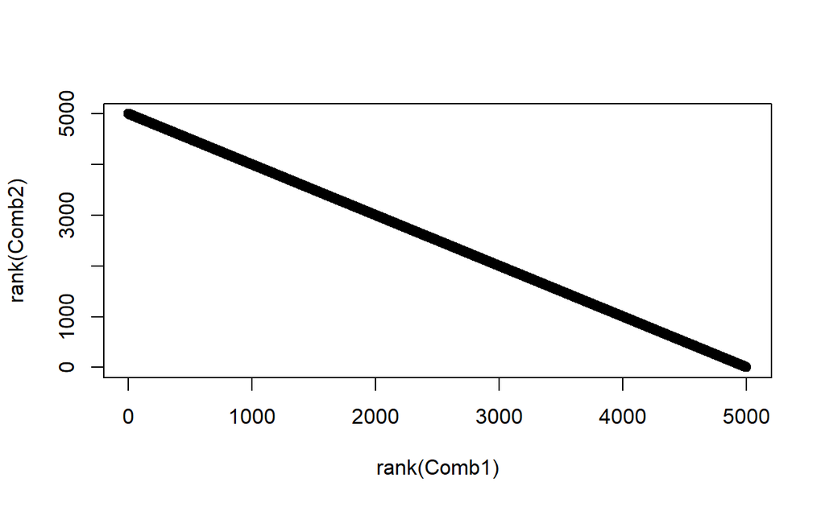

```r
plot(rank(Comb1),rank(Comb2))
```

Compare the models.

Using standard deviation:

```r
rbind(WithoutMetricPred=c(sd.contrast_1_5,sd.contrast_123_45),WithMetricPred=c(sd.contrast2_1_5,sd.contrast2_123_45))
```

```
                      [,1]     [,2]
WithoutMetricPred 4.256989 2.734301
WithMetricPred    2.995819 1.910106
```

Using HDI:

```r
rbind(WithoutMetricPred=c(hdiContrast_1_5,hdiContrast_123_45),WithMetricPred=c(hdiContrast2_1_5,hdiContrast2_123_45))
```

```
                     lower    upper     lower    upper
WithoutMetricPred 15.21982 31.95605  9.713508 20.41661
WithMetricPred    13.40625 25.09579 11.281726 18.74789
```

Using HDI width:

```r
rbind(WithoutMetricPred=c(Contrast_1_5=unname(diff(hdiContrast_1_5)),
                          Contrast_123_45=unname(diff(hdiContrast_123_45))),
      WithMetricPred=c(Contrast_1_5=diff(hdiContrast2_1_5),
                       Contrast_123_45=diff(hdiContrast2_123_45)))
```

```
                  Contrast_1_5 Contrast_123_45
WithoutMetricPred     16.73622       10.703103
WithMetricPred        11.68954        7.466168
```

Obviously, the width was shrinkage so with the metric predictor in the model, we can explain more the variability of Longevity due to the difference among groups and Thorax.

# Heterogeneous variances

The most restrictive assumption of ANOVA is equivalence of variances in all groups.

Look how Bayesian approach can remove this assumption.

The model uses t-distributed noise and allows each group to have its own standard deviation.

Data set `InsectSprays` from `datasets` shows test of 6 different insect sprays. Column count contains numbers of insects found in the field after each spraying. Column spray identifies the type of spray.

Prepare the data.

```r
df <- InsectSprays
head(df)
```

```
  count spray
1    10     A
2     7     A
3    20     A
4    14     A
5    14     A
6    12     A
```

```r
levels(df$spray)
```

```
[1] "A" "B" "C" "D" "E" "F"
```

```r
dataListSprays <- list(Ntotal = nrow(df),
                       y = df$count,
                       x = as.integer(df$spray),
                       NxLvl = nlevels(df$spray),
                       aGammaShRa = unlist(gammaShRaFromModeSD(mode=sd(df$count)/2,
                                                               sd=2*sd(df$count))))
```

Plot the data.

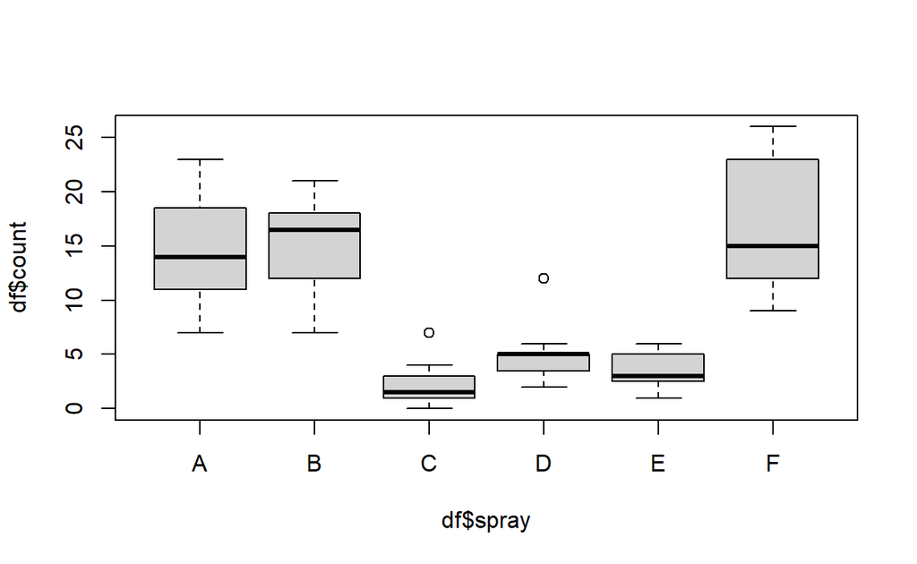

```r
plot(df$count ~ df$spray)
```

Note that variances within the groups are very different. If estimated overall the variance for groups “C”, “D” and “E” is overestimated and for “A” “B” and “F” - underestimated.

## Apply traditional ANOVA method.

```r
m1 <- lm(count~spray, df)
summary(m1)
```

```
Call:
lm(formula = count ~ spray, data = df)

Residuals:
   Min     1Q Median     3Q    Max
-8.333 -1.958 -0.500  1.667  9.333

Coefficients:
            Estimate Std. Error t value Pr(>|t|)
(Intercept)  14.5000     1.1322  12.807  < 2e-16 ***
sprayB        0.8333     1.6011   0.520    0.604
sprayC      -12.4167     1.6011  -7.755 7.27e-11 ***
sprayD       -9.5833     1.6011  -5.985 9.82e-08 ***
sprayE      -11.0000     1.6011  -6.870 2.75e-09 ***
sprayF        2.1667     1.6011   1.353    0.181
---
Signif. codes:  0 '***' 0.001 '**' 0.01 '*' 0.05 '.' 0.1 ' ' 1

Residual standard error: 3.922 on 66 degrees of freedom
Multiple R-squared:  0.7244,    Adjusted R-squared:  0.7036
F-statistic:  34.7 on 5 and 66 DF,  p-value: < 2.2e-16
```

```r
anova(m1)
```

```
Analysis of Variance Table

Response: count
          Df Sum Sq Mean Sq F value    Pr(>F)
spray      5 2668.8  533.77  34.702 < 2.2e-16 ***
Residuals 66 1015.2   15.38
---
Signif. codes:  0 '***' 0.001 '**' 0.01 '*' 0.05 '.' 0.1 ' ' 1
```

```r
#m.aov <- aov(count~spray, df)
#summary(m.aov)
```

The categorical factor is significant, i.e. utility test fails.

Create contrasts to identify differences between combinations of sprays.

```r
A <- factor(df$spray)
contrasts(A)
```

```
  B C D E F
A 0 0 0 0 0
B 1 0 0 0 0
C 0 1 0 0 0
D 0 0 1 0 0
E 0 0 0 1 0
F 0 0 0 0 1
```

```r
contrasts(A)<-cbind("GA vs GB"=c(1,-1,0,0,0,0),
                    "GAB vs GF"=c(1,1,0,0,0,-2),
                    "GC vs GD"=c(0,0,1,-1,0,0),
                    "GC vs GE"=c(0,0,1,0,-1,0),
                    "GABF vs GCDE"=c(1,1,-1,-1,-1,1))
A
```

```
 [1] A A A A A A A A A A A A B B B B B B B B B B B B C C C C C C C C C
[34] C C C D D D D D D D D D D D D E E E E E E E E E E E E F F F F F F
[67] F F F F F F
attr(,"contrasts")
  GA vs GB GAB vs GF GC vs GD GC vs GE GABF vs GCDE
A        1         1        0        0            1
B       -1         1        0        0            1
C        0         0        1        1           -1
D        0         0       -1        0           -1
E        0         0        0       -1           -1
F        0        -2        0        0            1
Levels: A B C D E F
```

```r
aov(df$count ~ A)
```

```
Call:
   aov(formula = df$count ~ A)

Terms:
                       A Residuals
Sum of Squares  2668.833  1015.167
Deg. of Freedom        5        66

Residual standard error: 3.921902
Estimated effects may be unbalanced
```

```r
summary.lm(aov(df$count ~ A))
```

```
Call:
aov(formula = df$count ~ A)

Residuals:
   Min     1Q Median     3Q    Max
-8.333 -1.958 -0.500  1.667  9.333

Coefficients:
                Estimate Std. Error t value Pr(>|t|)
(Intercept)    9.500e+00  4.622e-01  20.554   <2e-16 ***
AGA vs GB     -4.167e-01  8.006e-01  -0.520    0.604
AGAB vs GF    -5.833e-01  4.622e-01  -1.262    0.211
AGC vs GD     -1.417e+00  9.244e-01  -1.533    0.130
AGC vs GE      8.374e-16  9.244e-01   0.000    1.000
AGABF vs GCDE  6.000e+00  4.622e-01  12.981   <2e-16 ***
---
Signif. codes:  0 '***' 0.001 '**' 0.01 '*' 0.05 '.' 0.1 ' ' 1

Residual standard error: 3.922 on 66 degrees of freedom
Multiple R-squared:  0.7244,    Adjusted R-squared:  0.7036
F-statistic:  34.7 on 5 and 66 DF,  p-value: < 2.2e-16
```

Summary shows that sprays A and B, C and D, C and E are indistinguishable as well as combined observations of sprays A and B vs. F, but combined observations for sprays A, B, F are significantly different from C, D and E.

However, separate t-test of C vs. D shows significant difference and equivalence of C and E is almost rejected by t-test.

```r
t.test(df$count[df$spray=="C"], df$count[df$spray=="D"])
```

```
    Welch Two Sample t-test

data:  df$count[df$spray == "C"] and df$count[df$spray == "D"]
t = -3.0782, df = 20.872, p-value = 0.00573
alternative hypothesis: true difference in means is not equal to 0
95 percent confidence interval:
 -4.7482230 -0.9184437
sample estimates:
mean of x mean of y
 2.083333  4.916667
```

```r
t.test(df$count[df$spray=="C"], df$count[df$spray=="E"])
```

```
    Welch Two Sample t-test

data:  df$count[df$spray == "C"] and df$count[df$spray == "E"]
t = -1.868, df = 21.631, p-value = 0.07536
alternative hypothesis: true difference in means is not equal to 0
95 percent confidence interval:
 -2.9909888  0.1576555
sample estimates:
mean of x mean of y
 2.083333  3.500000
```

These contradicting results are caused by the fact that for comparison of C with D and E the assumption of homoscedasticity leads to overestimation of noise in general framework of ANOVA, but pairwise t-test is only accounting for variances of the compared pairs.

## Bayes’

Run MCMC.

```r
modelString<-"
data {
    int<lower=1> Ntotal;
    real y[Ntotal];
    int<lower=2> NxLvl;
    int<lower=1, upper=NxLvl> x[Ntotal];
    real<lower=0> aGammaShRa[2];
}
transformed data {
    real meanY;
    real sdY;
    meanY = mean(y);
    sdY = sd(y);
}
parameters {
    real<lower=0> nu;
    real a0;
    real<lower=0> aSigma;
    vector[NxLvl] a;
    real<lower=0> ySigma[NxLvl];
    real<lower=0> ySigmaMode;
    real<lower=0> ySigmaSD;
}
transformed parameters{
    real<lower=0> ySigmaSh;
    real<lower=0> ySigmaRa;
    ySigmaRa = ( ( ySigmaMode + sqrt( ySigmaMode^2 + 4*ySigmaSD^2 ) ) / ( 2*ySigmaSD^2 ) );
    ySigmaSh = 1 + ySigmaMode * ySigmaRa;
}
model {
    nu ~ exponential(1/30.0);
    a0 ~ normal(meanY, 10*sdY);
    aSigma ~ gamma(aGammaShRa[1], aGammaShRa[2]);
    a ~ normal(0, aSigma);
    ySigma ~ gamma(ySigmaSh, ySigmaRa);
    ySigmaMode ~ gamma(aGammaShRa[1], aGammaShRa[2]);
    ySigmaSD ~ gamma(aGammaShRa[1], aGammaShRa[2]);
    for ( i in 1:Ntotal ) {
        y[i] ~ student_t(nu, a0 + a[x[i]], ySigma[x[i]]);
    }
}
generated quantities {
    // Convert a0,a[] to sum-to-zero b0,b[] :
        real b0;
    vector[NxLvl] b;
    b0 = a0 + mean(a);
    b = a - mean(a);
}
"
```

```r
model3 <- stan_model(model_code = modelString)
```

```r
# saveRDS(model3,file = "data/stanDSO3.Rds")
model3 <- readRDS(file = "data/stanDSO3.Rds")
```

Run chains.

```r
fit.sprays <- sampling(model3,
                data=dataListSprays,
                pars=c('b0', 'b', 'aSigma', 'ySigma', 'nu', 'ySigmaMode', 'ySigmaSD'),
                iter=5000, chains = 2, cores = 4)
```

```r
launch_shinystan(fit)
```

Analyze estimates.

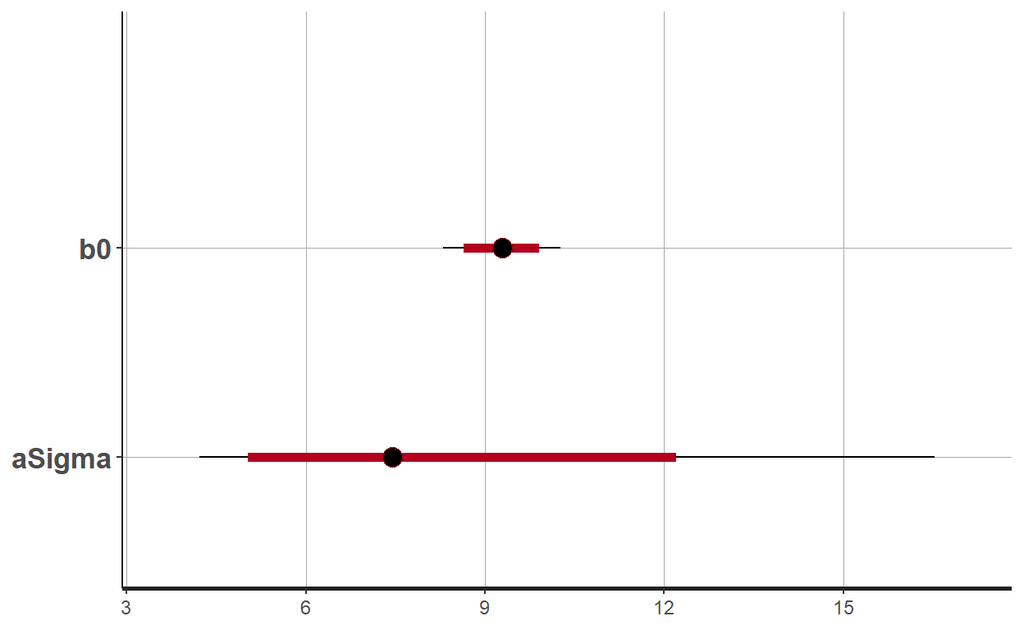

```r
plot(fit.sprays,pars=c("b0","aSigma"))
```

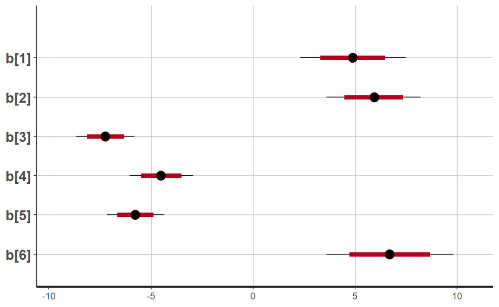

```r
plot(fit.sprays,pars=c("b"))
```

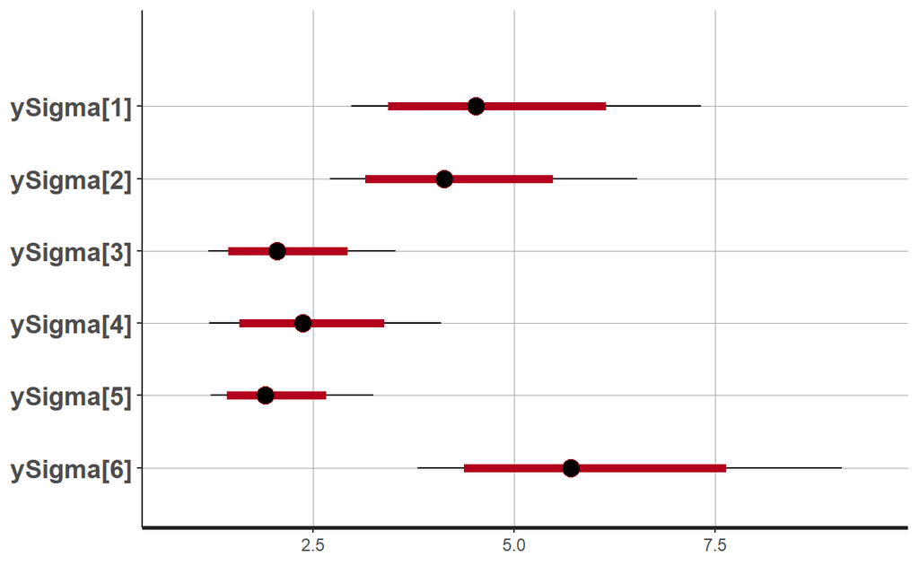

```r
plot(fit.sprays,pars=c("ySigma"))
```

Extract chains.

```r
chains_sprays <- rstan::extract(fit.sprays)
head(chains_sprays$b)
```

```
iterations     [,1]     [,2]      [,3]      [,4]      [,5]     [,6]
      [1,] 5.321336 5.903195 -7.231029 -5.126114 -5.243187 6.375798
      [2,] 6.009771 4.809611 -7.284751 -4.387986 -6.658077 7.511432
      [3,] 3.685636 5.496733 -6.662345 -3.278268 -5.640332 6.398575
      [4,] 3.609592 4.813631 -6.971538 -2.848964 -6.461671 7.858950
      [5,] 7.089465 4.230392 -7.824936 -5.013679 -6.613809 8.132567
      [6,] 4.836717 6.068238 -6.645967 -4.104199 -5.881397 5.726608
```

Look at the same contrasts.

1. A vs. B

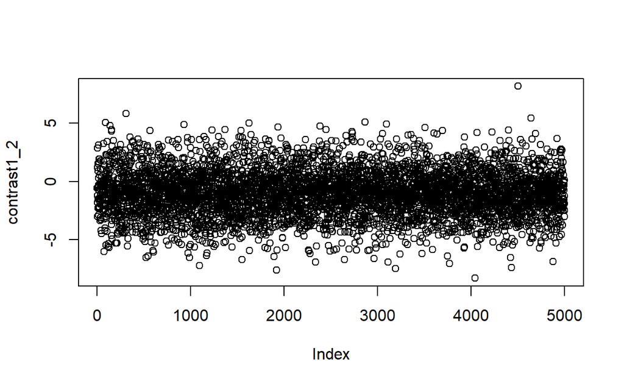

```r
contrast1_2 <- chains_sprays$b[,1] - chains_sprays$b[,2]
plot(contrast1_2)
```

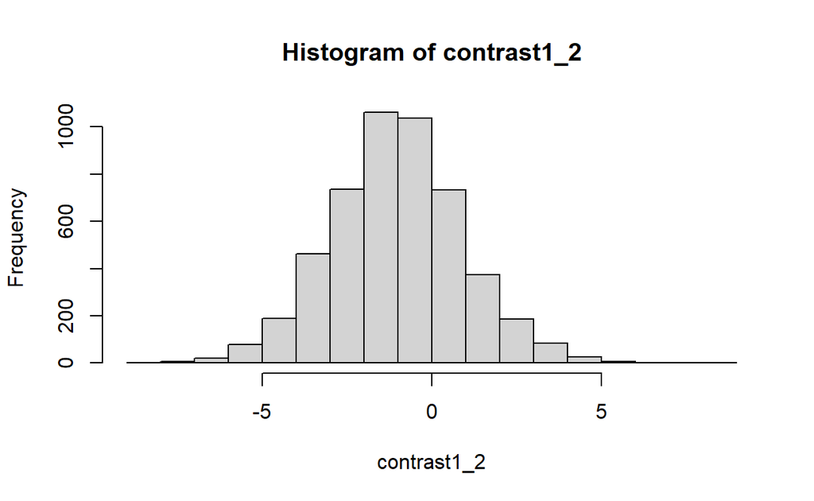

```r
hist(contrast1_2)
```

```r
(hdiContrast1_2<-hdi(contrast1_2))
```

```
    lower     upper
-4.566850  3.072822
attr(,"credMass")
[1] 0.95
```

```r
(sd.contrast1_2<-sd(contrast1_2))
```

```
[1] 1.92444
```

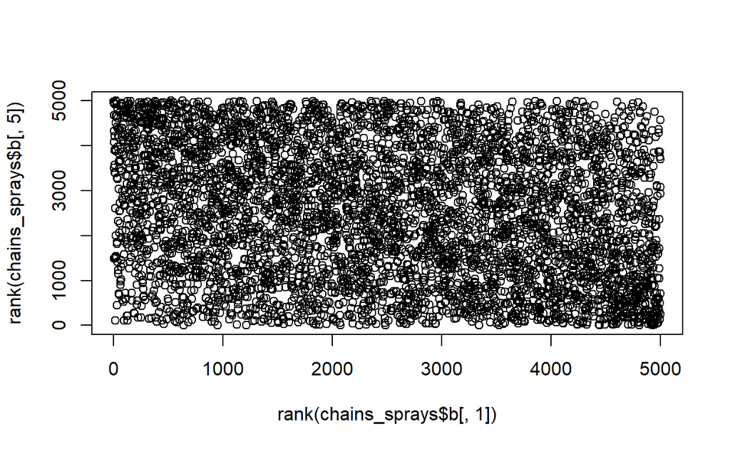

```r
plot(rank(chains_sprays$b[,1]),rank(chains_sprays$b[,5]))
```

The contrast is not different from zero.

2. A, B vs. F

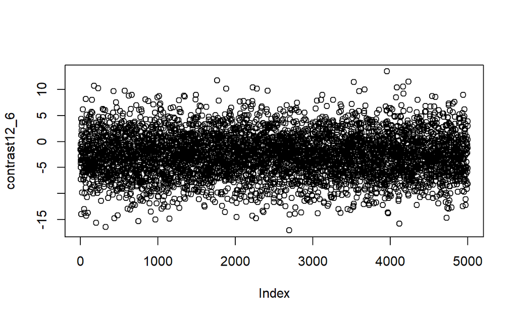

```r
Comb1<-chains_sprays$b[,1] + chains_sprays$b[,2]
Comb2<-2*chains_sprays$b[,6]
contrast12_6 <-Comb1  - Comb2
plot(contrast12_6)
```

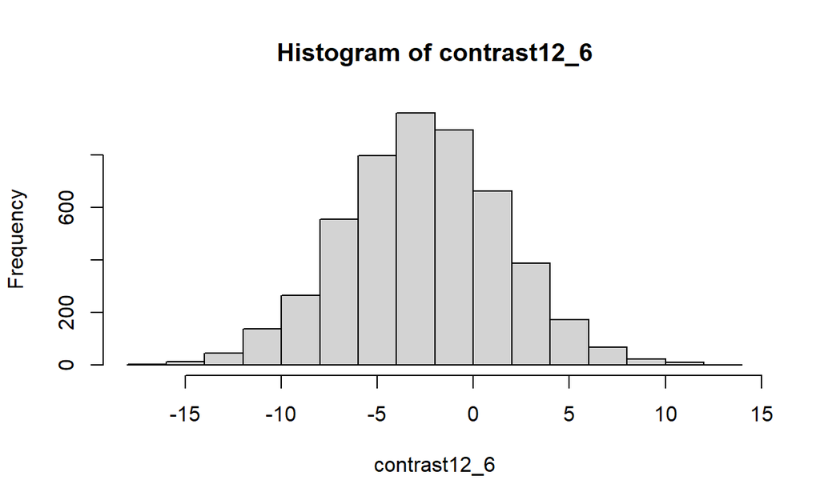

```r
hist(contrast12_6)
```

```r
(hdiContrast12_6<-hdi(contrast12_6))
```

```
    lower     upper
-11.15426   5.21297
attr(,"credMass")
[1] 0.95
```

```r
(sd.contrast12_6<-sd(contrast12_6))
```

```
[1] 4.148463
```

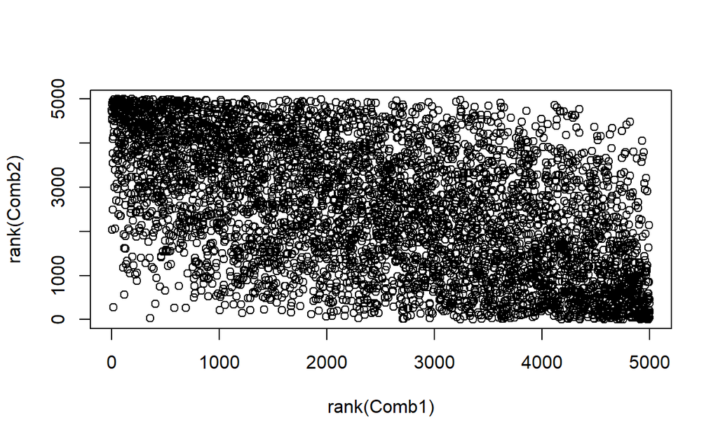

```r
plot(rank(Comb1),rank(Comb2))
```

The contrast is not different from zero.

3. C vs. D

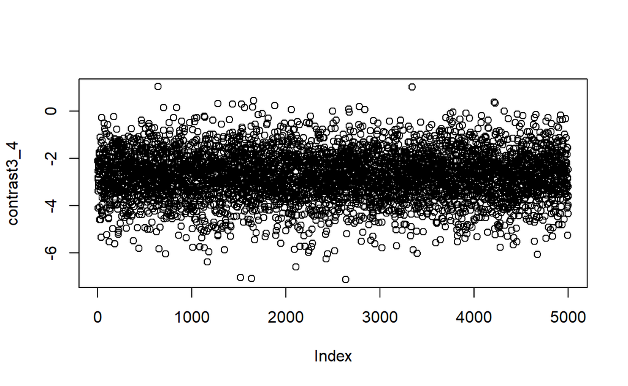

```r
contrast3_4 <- chains_sprays$b[,3] - chains_sprays$b[,4]
plot(contrast3_4)
```

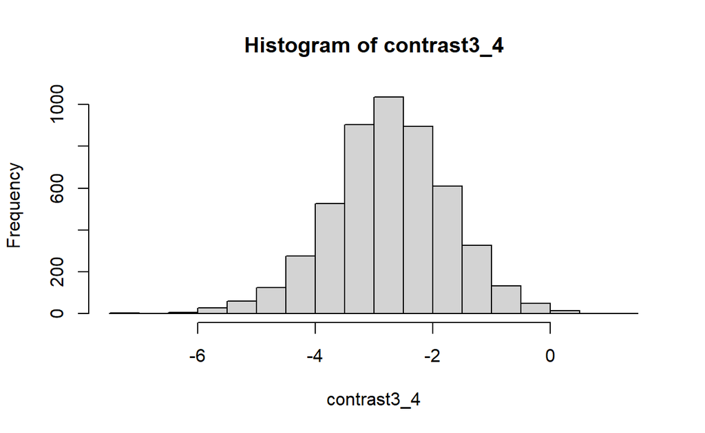

```r
hist(contrast3_4)
```

```r
(hdiContrast3_4<-hdi(contrast3_4))
```

```
     lower      upper
-4.8309758 -0.7441633
attr(,"credMass")
[1] 0.95
```

```r
(sd.contrast3_4<-sd(contrast3_4))
```

```
[1] 1.01399
```

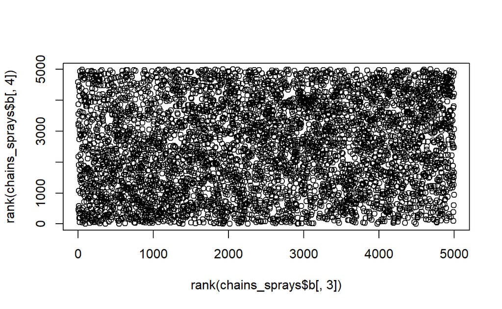

```r
plot(rank(chains_sprays$b[,3]),rank(chains_sprays$b[,4]))
```

This contrast is different from zero. ANOVA could not detect that.

4. C vs. E

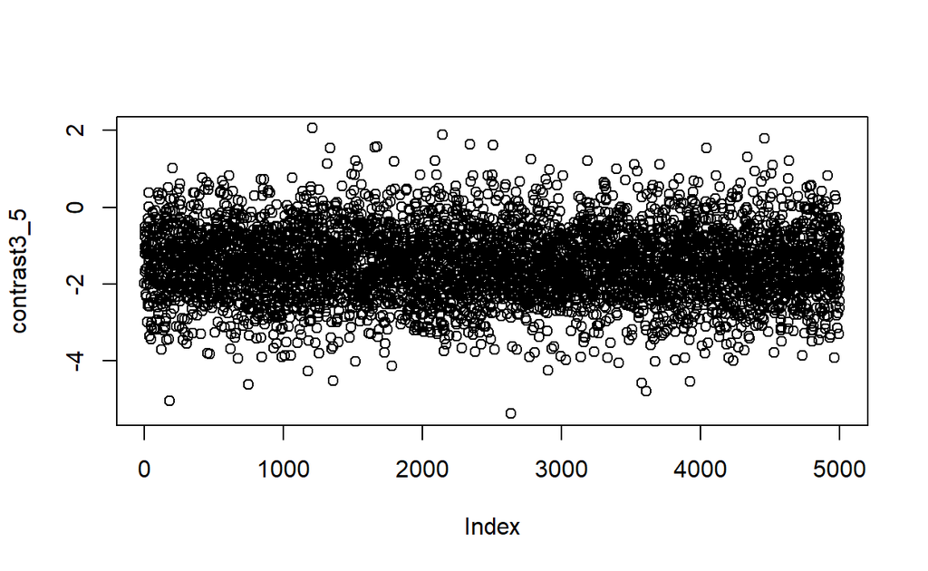

```r
contrast3_5 <- chains_sprays$b[,3] - chains_sprays$b[,5]
plot(contrast3_5)
```

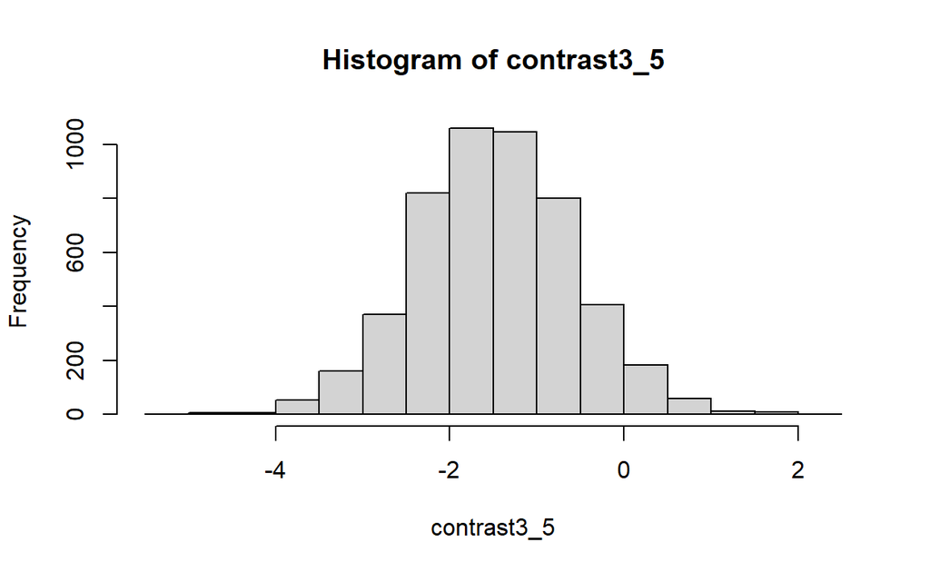

```r
hist(contrast3_5)
```

```r
(hdiContrast3_5<-hdi(contrast3_5))
```

```
    lower     upper
-3.206783  0.386665
attr(,"credMass")
[1] 0.95
```

```r
(sd.contrast3_5<-sd(contrast3_5))
```

```
[1] 0.9066876
```

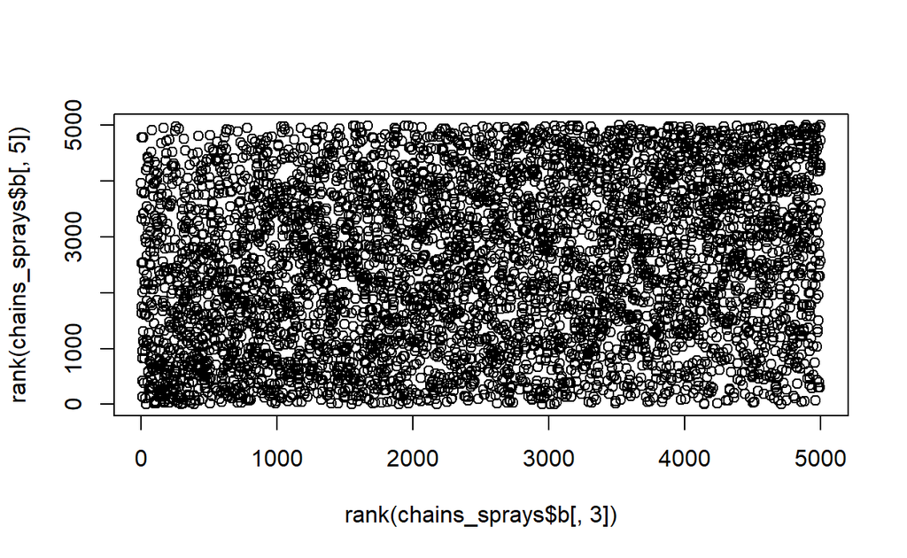

```r
plot(rank(chains_sprays$b[,3]),rank(chains_sprays$b[,5]))
```

The contrast is not different from zero.

5. Combined observations A, B and F vs. C, D, E

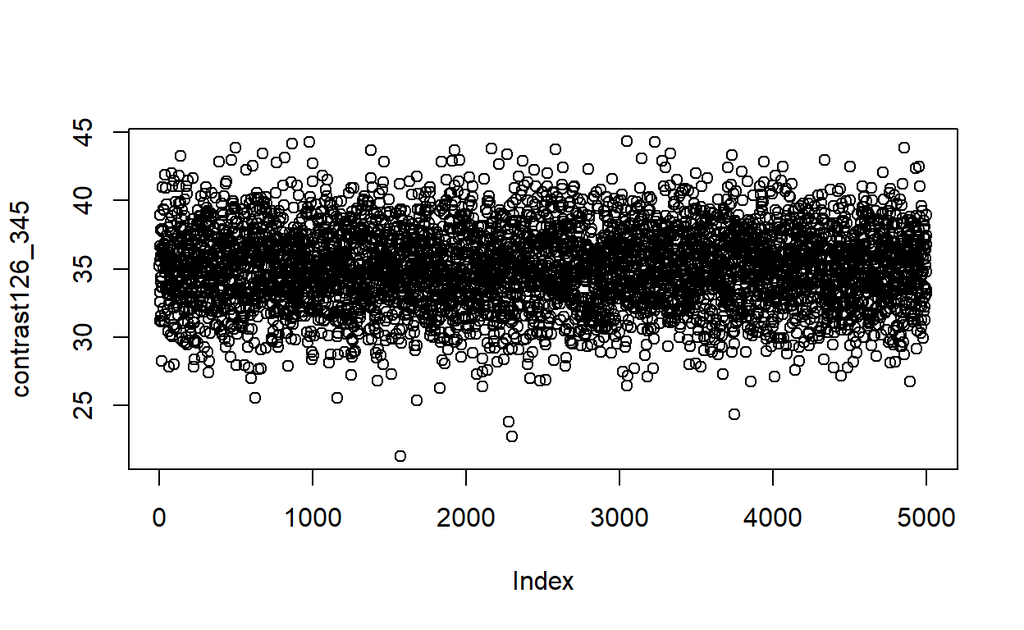

```r
Comb1<-chains_sprays$b[,1] + chains_sprays$b[,2] + chains_sprays$b[,6]
Comb2<-chains_sprays$b[,3] + chains_sprays$b[,4] + chains_sprays$b[,5]
contrast126_345 <-Comb1  - Comb2
plot(contrast126_345)
```

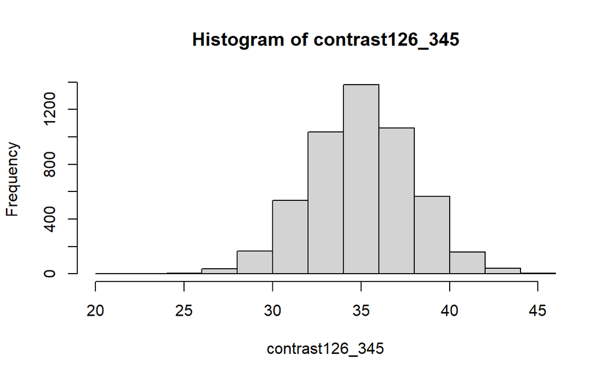

```r
hist(contrast126_345)
```

```r
(hdiContrast126_345<-hdi(contrast126_345))
```

```
   lower    upper
29.35368 40.63068
attr(,"credMass")
[1] 0.95
```

```r
(sd.contrast126_345<-sd(contrast126_345))
```

```
[1] 2.911281
```

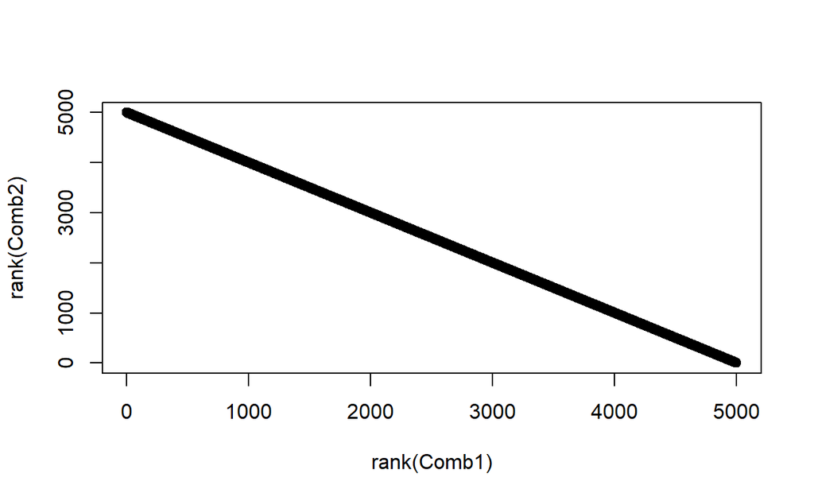

```r
plot(rank(Comb1),rank(Comb2))
```

The contrast is significantly different from zero.

# Further Readings

Adapted from UC’s coursework

Kruschke, John K. 2015. *Doing Bayesian Data Analysis : A Tutorial with r, JAGS, and Stan*. Book. 2E [edition]. Amsterdam: Academic Press is an imprint of Elsevier.